# IDS572-HW4

Amin Abbasi

2024-11-23

```
install.packages("smotefamily")
install.packages("DMwR2")
install.packages("caret")
install.packages("rpart")   # Install and load rpart for decision trees
install.packages("randomForest") # Install and load randomForest
install.packages("e1071") # Install and load e1071 for Naive Bayes
install.packages("adabag")  # Install and load adabag for AdaBoost
```

```r
library(readxl)  # For reading Excel files
library(smotefamily)
library(DMwR2)
library(caret)
```

```r
library(ggplot2)
library(reshape2)
library(rpart)
library(pROC) # for ROC curve
library(randomForest)
library(e1071)
library(adabag)
```

##Importing the Dataset

```r
# Load your dataset (replace 'your_dataset.csv' with your actual dataset file)
data <- read_excel("Retention Modeling at Scholastic Travel Company (A)_ Student Spreadsheet.xlsx", sheet = "Data")
# Convert the target variable to a factor
data$Retained.in.2012. <- as.factor(data$Retained.in.2012.)
```

##Exploring the dataset

```r
# View the structure of the dataset
str(data)
```

```
## tibble [2,392 × 56] (S3: tbl_df/tbl/data.frame)
##  $ ID                            : num [1:2392] 1 2 3 4 5 6 7 8 9 10 ...
##  $ Program.Code                  : chr [1:2392] "HS" "HC" "HD" "HN" ...
##  $ From.Grade                    : chr [1:2392] "4" "8" "8" "9" ...
##  $ To.Grade                      : chr [1:2392] "4" "8" "8" "12" ...
##  $ Group.State                   : chr [1:2392] "CA" "AZ" "FL" "VA" ...
##  $ Is.Non.Annual.                : num [1:2392] 0 0 0 1 0 0 1 0 0 0 ...
##  $ Days                          : num [1:2392] 1 7 3 3 6 4 6 8 8 4 ...
##  $ Travel.Type                   : chr [1:2392] "A" "A" "A" "B" ...
##  $ Departure.Date                : POSIXct[1:2392], format: "2011-01-14" "2011-01-14" ...
##  $ Return.Date                   : POSIXct[1:2392], format: "2011-01-14" "2011-01-21" ...
##  $ Deposit.Date                  : POSIXct[1:2392], format: "2010-08-30" "2009-11-15" ...
##  $ Special.Pay                   : chr [1:2392] "NA" "CP" "NA" "NA" ...
##  $ Tuition                       : num [1:2392] 424 2350 1181 376 865 ...
##  $ FRP.Active                    : num [1:2392] 25 9 17 0 40 9 16 10 30 51 ...
```

[output cut: 42 more lines]

```r
# Get a summary of the dataset
summary(data)
```

```
##        ID       Program.Code        From.Grade          To.Grade
##  Min.   :   1   Length:2392        Length:2392        Length:2392
##  1st Qu.: 598   Class :character   Class :character   Class :character
##  Median :1195   Mode  :character   Mode  :character   Mode  :character
##  Mean   :1195
##  3rd Qu.:1792
##  Max.   :2389
##  NA's   :3
##  Group.State        Is.Non.Annual.       Days        Travel.Type
##  Length:2392        Min.   :0.000   Min.   : 1.000   Length:2392
##  Class :character   1st Qu.:0.000   1st Qu.: 4.000   Class :character
##  Mode  :character   Median :0.000   Median : 5.000   Mode  :character
##                     Mean   :0.154   Mean   : 4.575
##                     3rd Qu.:0.000   3rd Qu.: 5.000
##                     Max.   :1.000   Max.   :12.000
##                     NA's   :3       NA's   :3
##  Departure.Date                    Return.Date
##  Min.   :2011-01-14 00:00:00.00   Min.   :2011-01-14 00:00:00.00
##  1st Qu.:2011-04-09 00:00:00.00   1st Qu.:2011-04-12 00:00:00.00
##  Median :2011-05-17 00:00:00.00   Median :2011-05-20 00:00:00.00
##  Mean   :2011-05-07 18:20:38.68   Mean   :2011-05-11 11:57:53.42
##  3rd Qu.:2011-06-07 00:00:00.00   3rd Qu.:2011-06-10 00:00:00.00
##  Max.   :2011-06-30 00:00:00.00   Max.   :2011-07-05 00:00:00.00
##  NA's   :3                        NA's   :3
##   Deposit.Date                    Special.Pay           Tuition
##  Min.   :2009-09-25 00:00:00.00   Length:2392        Min.   :  79
##  1st Qu.:2010-10-15 00:00:00.00   Class :character   1st Qu.:1174
##  Median :2010-10-28 00:00:00.00   Mode  :character   Median :1700
##  Mean   :2010-10-24 19:42:37.22                      Mean   :1615
##  3rd Qu.:2010-11-05 00:00:00.00                      3rd Qu.:2048
##  Max.   :2011-10-30 00:00:00.00                      Max.   :4200
##  NA's   :3                                           NA's   :3
##    FRP.Active     FRP.Cancelled    FRP.Take.up.percent.  Early.RPL
##  Min.   :  0.00   Min.   : 0.000   Min.   :0.0000       Length:2392
##  1st Qu.:  6.00   1st Qu.: 1.000   1st Qu.:0.4550       Class :character
##  Median : 12.00   Median : 2.000   Median :0.6000       Mode  :character
##  Mean   : 16.87   Mean   : 3.306   Mean   :0.5707
##  3rd Qu.: 23.00   3rd Qu.: 4.000   3rd Qu.:0.7270
##  Max.   :257.00   Max.   :45.000   Max.   :1.0000
##  NA's   :3        NA's   :3        NA's   :3
```

[output cut: 81 more lines]

```
##  Length:2392              Min.   :0.6000   Min.   : 0.000
##  Class :character         1st Qu.:0.8824   1st Qu.: 1.000
##  Mode  :character         Median :0.9091   Median : 2.000
##                           Mean   :0.9007   Mean   : 2.954
##                           3rd Qu.:0.9333   3rd Qu.: 4.000
##                           Max.   :1.0000   Max.   :47.000
##                           NA's   :3        NA's   :3
##  SchoolSizeIndicator Retained.in.2012.
##  Length:2392         0   : 938
##  Class :character    1   :1451
##  Mode  :character    NA's:   3
##
##
##
##
```

##Preprocessing Data

```r
# Remove specific columns by name
data <- data[, !names(data) %in% c("Return.Date", "Deposit.Date", "Departure.Date", "Early.RPL", "Latest.RPL", "FirstMeeting", "LastMeeting", "Initial.System.Date","ID" )]

# Check the structure of the updated dataset
#str(data)  # Confirm that the columns have been removed


# Replace "NA" and "" with NA in all columns
data <- data.frame(lapply(data, function(column) {
  # Replace empty strings or "NA" (string) with actual NA
  column[column == "" | column == "NA"] <- NA
  return(column)
}), stringsAsFactors = FALSE)
```

#Handling Missing Values Check Missing Values in Each Column

```r
# Count missing values in each column
colSums(is.na(data))
```

```
##                   Program.Code                     From.Grade
##                              3                            130
##                       To.Grade                    Group.State
##                            153                              3
##                 Is.Non.Annual.                           Days
##                              3                              3
##                    Travel.Type                    Special.Pay
##                              3                           1922
##                        Tuition                     FRP.Active
##                              3                              3
##                  FRP.Cancelled           FRP.Take.up.percent.
##                              3                              3
##                  Cancelled.Pax             Total.Discount.Pax
##                              3                              3
##                   Poverty.Code                         Region
##                            602                              3
##                    CRM.Segment                    School.Type
##                              7                              3
##            Parent.Meeting.Flag                  MDR.Low.Grade
##                              3                             71
##                 MDR.High.Grade        Total.School.Enrollment
##                             71                             94
##                   Income.Level            EZ.Pay.Take.Up.Rate
##                             65                              3
##                 School.Sponsor               SPR.Product.Type
##                              3                              3
##               SPR.New.Existing                            FPP
##                              3                              3
##                      Total.Pax              SPR.Group.Revenue
##                              3                              3
##    NumberOfMeetingswithParents DifferenceTraveltoFirstMeeting
##                              3                            340
##  DifferenceTraveltoLastMeeting             SchoolGradeTypeLow
##                            340                              3
##            SchoolGradeTypeHigh                SchoolGradeType
##                              3                              3
##                 DepartureMonth              GroupGradeTypeLow
##                              3                              3
##             GroupGradeTypeHigh                 GroupGradeType
##                              3                              3
##               MajorProgramCode            SingleGradeTripFlag
##                              3                              3
##       FPP.to.School.enrollment                     FPP.to.PAX
##                             94                              3
##             Num.of.Non_FPP.PAX            SchoolSizeIndicator
##                              3                             94
##              Retained.in.2012.
##                              3
```

#handle missing values in the dataset by replacing:

```r
# Load the dataset
data <- read.csv("Step1_removeNAs.csv", stringsAsFactors = FALSE)

# Function to calculate the mode
calculate_mode <- function(column) {
  unique_values <- unique(column)
  unique_values <- unique_values[!is.na(unique_values)]  # Exclude NA from calculation
  mode_value <- unique_values[which.max(tabulate(match(column, unique_values)))]
  return(mode_value)
}

# Separate numeric and categorical columns
numeric_columns <- sapply(data, is.numeric)
categorical_columns <- sapply(data, is.character)

# Replace missing values in numeric columns with the mean
data[numeric_columns] <- lapply(data[numeric_columns], function(column) {
  ifelse(is.na(column), median(column, na.rm = TRUE), column)
})

# Replace missing values in categorical columns with the mode
data[categorical_columns] <- lapply(data[categorical_columns], function(column) {
  column[is.na(column)] <- calculate_mode(column)
  return(column)
})

# Total number of missing values in the dataset
total_missing <- sum(is.na(data))

# Print the result
print(paste("Total number of missing values in the dataset:", total_missing))
```

```
## [1] "Total number of missing values in the dataset: 0"
```

Now there are no Missing Value in the dataset

#Handling Outliers

#Cap Outliers cap the values at the IQR thresholds

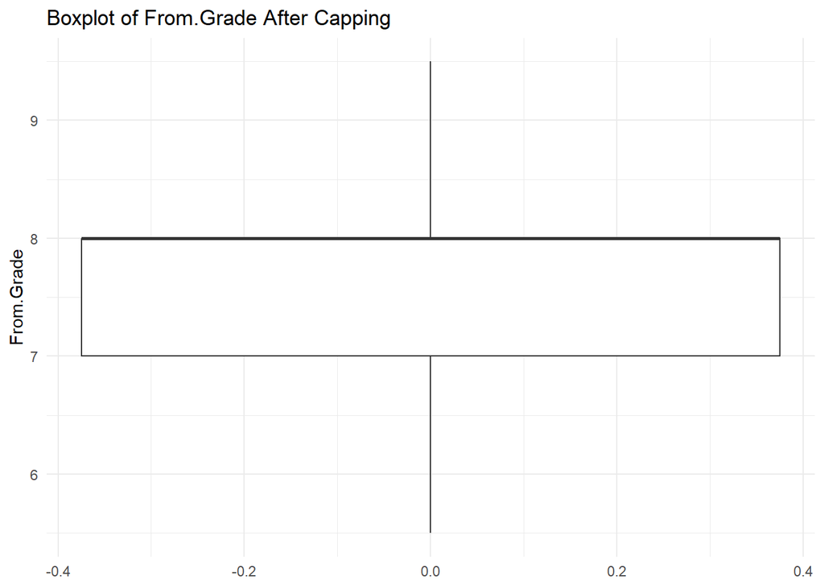

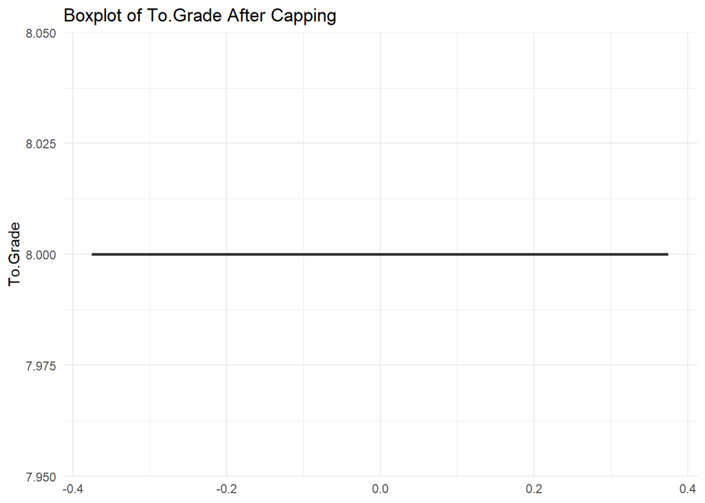

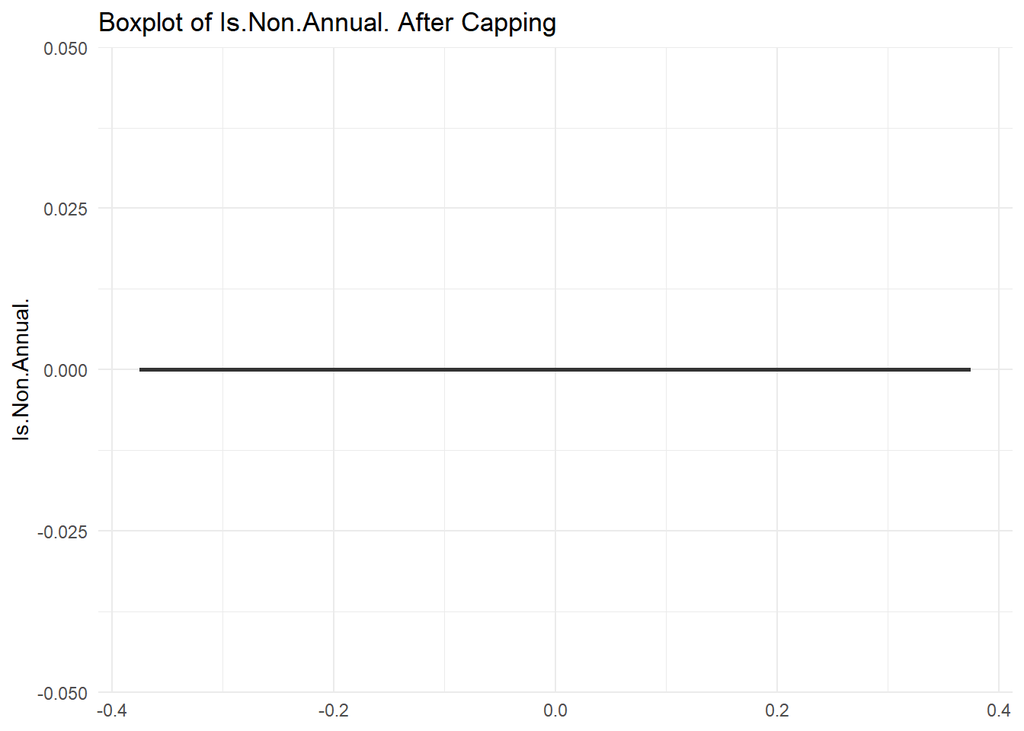

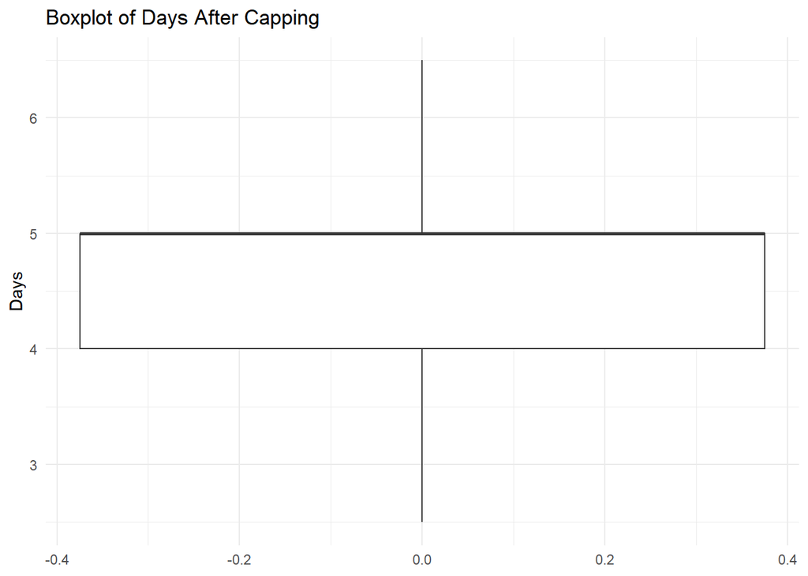

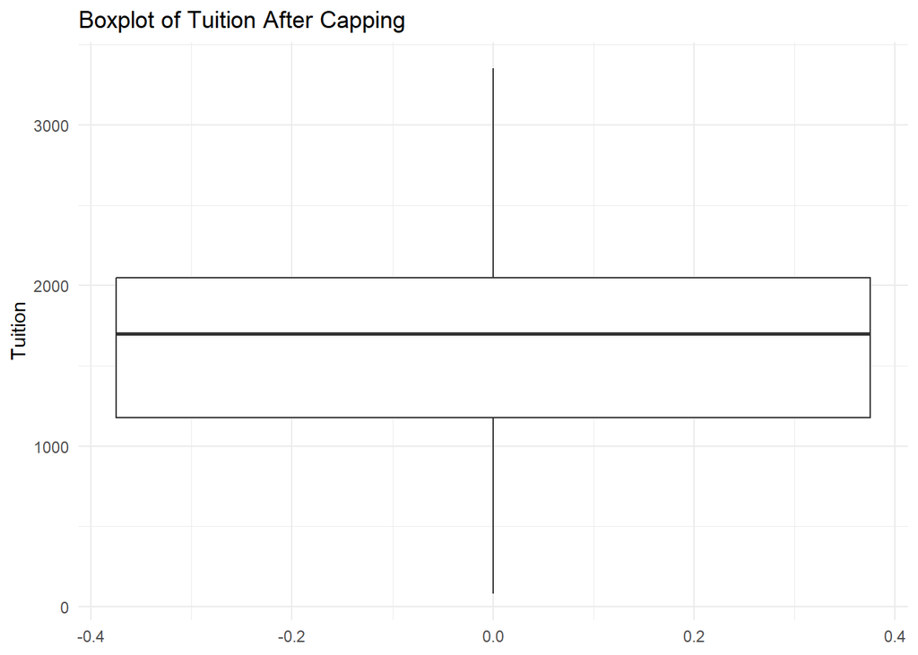

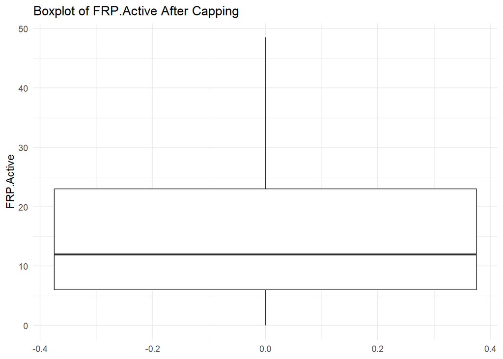

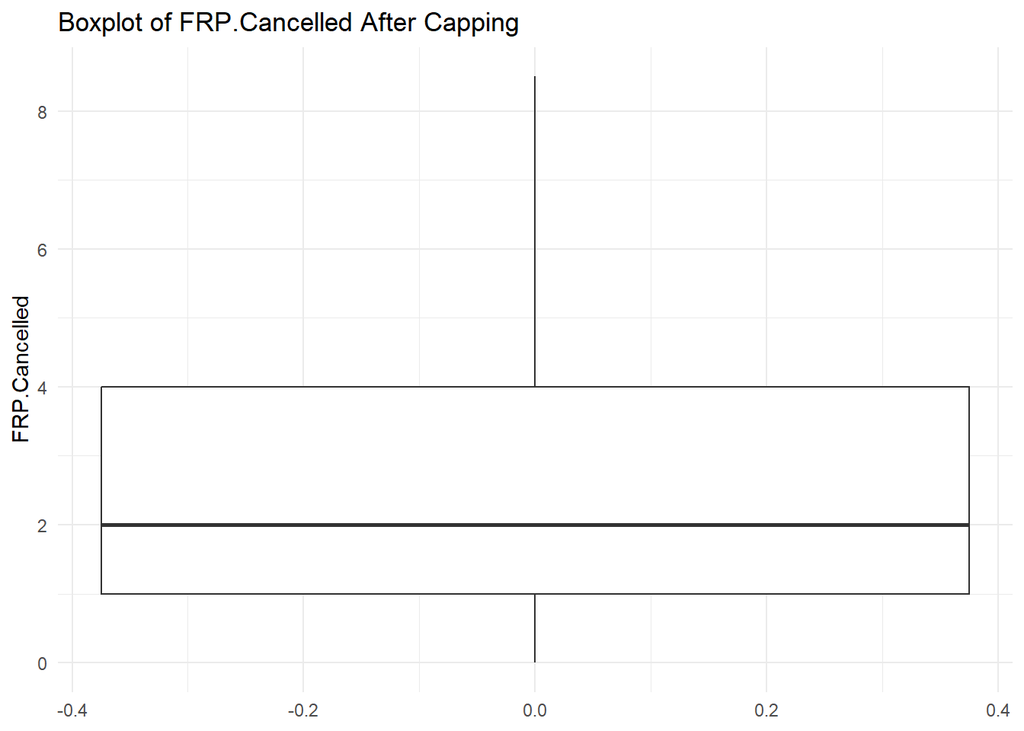

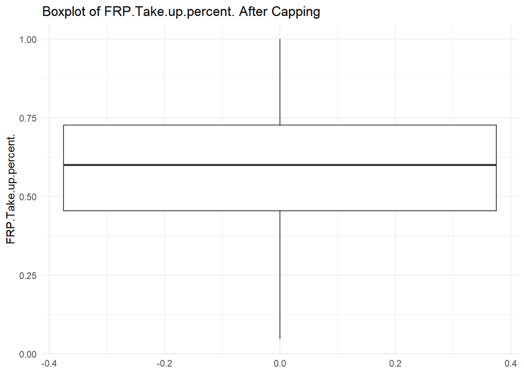

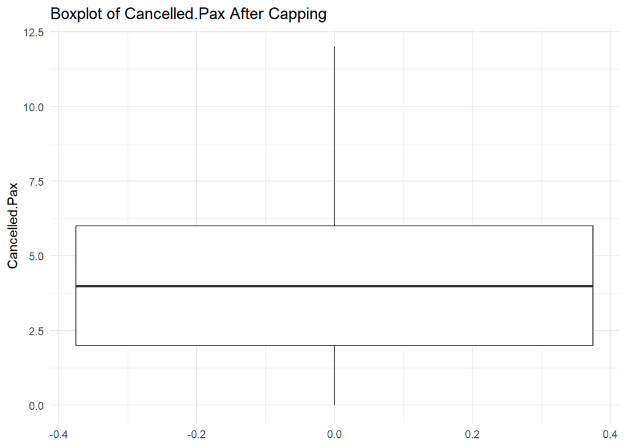

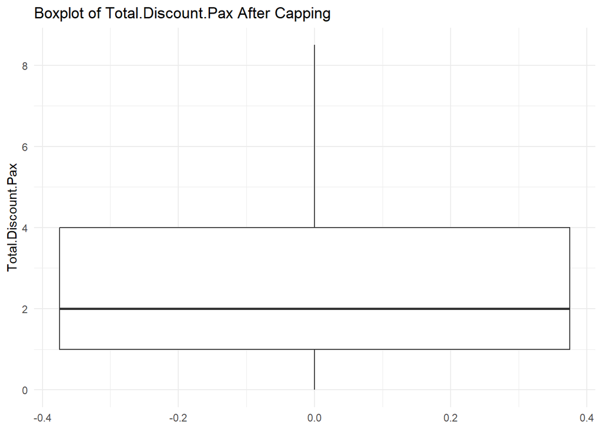

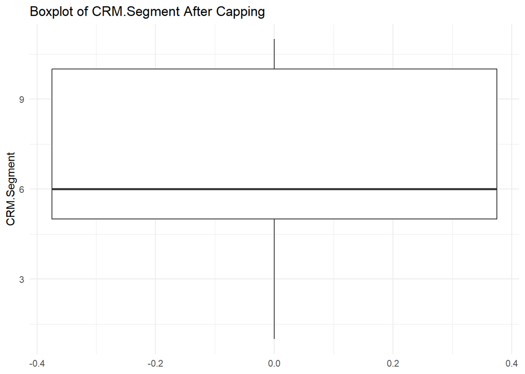

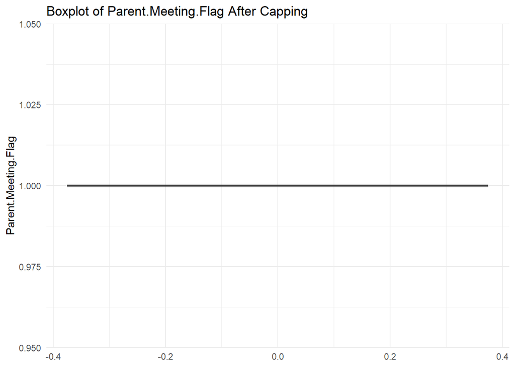

[15 more figures not shown]

```r
handle_outliers_iqr_cap <- function(data) {
  numeric_columns <- sapply(data, is.numeric)  # Identify numeric columns

  data[numeric_columns] <- lapply(data[numeric_columns], function(column) {
    if (is.numeric(column)) {
      Q1 <- quantile(column, 0.25, na.rm = TRUE)
      Q3 <- quantile(column, 0.75, na.rm = TRUE)
      IQR <- Q3 - Q1
      lower_bound <- Q1 - 1.5 * IQR
      upper_bound <- Q3 + 1.5 * IQR

      # Cap the values at lower and upper bounds
      column[column < lower_bound] <- lower_bound
      column[column > upper_bound] <- upper_bound
    }
    return(column)
  })

  return(data)
}

# Apply the capping method
data_capped <- handle_outliers_iqr_cap(data)

# Visualize boxplots again
library(ggplot2)
numeric_columns <- names(data_capped)[sapply(data_capped, is.numeric)]
for (column_name in numeric_columns) {
  print(
    ggplot(data_capped, aes_string(y = column_name)) +
      geom_boxplot(outlier.colour = "red", outlier.shape = 16, outlier.size = 2) +
      labs(title = paste("Boxplot of", column_name, "After Capping"), y = column_name) +
      theme_minimal()
  )
}
```

#handeling Rare Values in Cat columns Identify Rare Categories

```r
#  threshold 0.5%  for rare categories
threshold <- 0.005

# Identify rare categories for each categorical column
categorical_columns <- sapply(data, is.character)  # Identify categorical columns
rare_categories <- lapply(data[, categorical_columns], function(column) {
  freq_table <- prop.table(table(column))
  names(freq_table[freq_table < threshold])  # Return rare categories
})

# Print rare categories for each column
rare_categories
```

```
## $Program.Code
##  [1] "CN"  "CVP" "FN"  "HF"  "HH"  "HIS" "HO"  "HP"  "HW"  "HX"  "HY"  "HZ"
## [13] "IK"  "SD"
##
## $Group.State
##  [1] "AB"             "AK"             "AR"             "Bermuda"
##  [5] "Cayman Islands" "HI"             "ME"             "MS"
##  [9] "MT"             "MX"             "ND"             "NH"
## [13] "NJ"             "PA"             "PR"             "RI"
## [17] "SC"             "SD"             "UT"             "VT"
## [21] "WV"             "WY"
##
## $Travel.Type
## [1] "N" "T"
##
## $Special.Pay
## character(0)
##
## $Poverty.Code
## [1] "0"
##
## $Region
## character(0)
##
## $School.Type
## character(0)
##
## $MDR.Low.Grade
## [1] "1"  "10" "2"
##
## $Income.Level
## [1] "P1" "P3" "P4" "P5"
##
## $SPR.Product.Type
## [1] "IL History"
##
## $SPR.New.Existing
## character(0)
##
## $SchoolGradeTypeLow
```

[output cut: 10 more lines]

```
##
## $GroupGradeTypeLow
## character(0)
##
## $GroupGradeTypeHigh
## character(0)
##
## $GroupGradeType
## [1] "Elementary->Elementary" "Elementary->High"
##
## $MajorProgramCode
## character(0)
##
## $SchoolSizeIndicator
## character(0)
```

Handle Rare Categories by group Rare Categories into “Other”: Combine rare categories into a single group labeled “Other”.

```r
# Combine rare categories into "Other"
data[, categorical_columns] <- lapply(names(data)[categorical_columns], function(col_name) {
  column <- data[[col_name]]
  freq_table <- prop.table(table(column))
  rare_values <- names(freq_table[freq_table < threshold])
  column[column %in% rare_values] <- "Other"
  return(column)
})
```

```r
# Check the frequency distribution after handling rare values
for (col_name in names(data)[categorical_columns]) {
  print(table(data[[col_name]]))
}
```

```
##
##    CC    CD    HC    HD    HG    HN    HS   HVP    IC Other    SC    SG    SK
##    14   114   274  1433    25    73   131    62    12    69    46    20    68
##    SM    ST
##    23    28
##
##    AL    AZ    CA    CO    CT    FL    GA    IA    ID    IL    IN    KS    KY
##    21    53   721    89    15    62    22    35    14   104    43    26    16
##    LA    MA    MD    MI    MN    MO    NC    NE    NM    NV    NY    OH    OK
##    31    36    15    71    51    43    16    42    20    20    19    53    33
##    OR Other    TN    TX    VA    WA    WI
##    51   113    38   308    18   147    46
##
##     A     B Other
##  2017   367     8
##
##   CP   FR   SA
##   70 2215  107
##
##     A     B     C     D     E Other
##   265  1563   507    36    17     4
##
##              Dallas             Houston Northern California               Other
##                 163                 145                 275                1168
##   Pacific Northwest Southern California
##                 198                 443
##
##              Catholic                   CHD Private non-Christian
##                   163                   257                   151
##                PUBLIC
##                  1821
##
##     3     4     5     6     7     8     9     K Other    PK
##    12    17    96   959   348    14   104   428    13   401
##
##     A     B     C     D     E     F     G     H     I     J     K     L     M
##    20    33    67    41    80   105    91    85   159   160   123   214   189
##     N     O Other     P     Q     Z
##   148   266     7   212   348    44
##
```

[output cut: 29 more lines]

```
##
##   Elementary->Middle           High->High        K->Elementary
##                  120                  107                   71
##              K->High            K->Middle         Middle->High
##                   52                  305                  147
##       Middle->Middle                Other       PK->Elementary
##                 1106                   15                   31
##             PK->High           PK->Middle Undefined->Undefined
##                  104                  266                   68
##
##    C    H    I    S
##  135 2052   16  189
##
##   L M-L   S S-M
## 597 594 507 694
```

#Check Balance

```r
# Check the class distribution of the target variable
table(data$Retained.in.2012.)
```

```
##
##    0    1
##  938 1454
```

```r
# Calculate the proportion of each class
prop.table(table(data$Retained.in.2012.))
```

```
##
##         0         1
## 0.3921405 0.6078595
```

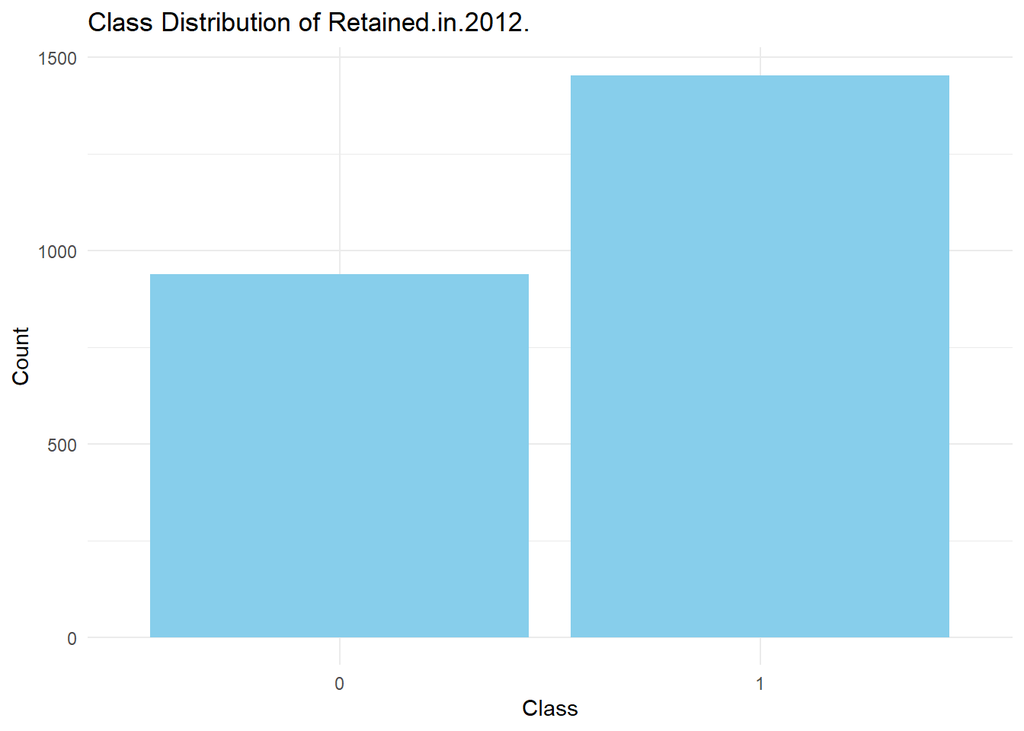

```r
# Visualize the class distribution
library(ggplot2)

ggplot(data, aes(x = as.factor(Retained.in.2012.))) +
  geom_bar(fill = "skyblue") +
  labs(title = "Class Distribution of Retained.in.2012.", x = "Class", y = "Count") +
  theme_minimal()
```

The dataset has some imbalance, but it is not severe (about a 60-40 split) and logistic regression, decision trees, and random forests can handle mild imbalances reasonably well, However Algorithms like neural networks may perform better with balanced data.Additionally because the cost of misclassifying the minority class (0) is high and we must use Evaluate performance like precision, recall, F1-score, and ROC-AUC, I consider balancing.

```r
# Apply undersampling
downsampled_data <- downSample(x = data[, -which(names(data) == "Retained.in.2012.")],
                               y = as.factor(data$Retained.in.2012.))

# Check the new class distribution
table(downsampled_data$Class)
```

```
##
##   0   1
## 938 938
```

#Normalization

I dicided to Normalize the data because there are some features with large values (e.g., tuition) can dominate the model’s calculations, overshadowing features with smaller values (e.g., rates) to ensures that all features contribute equally to the model.

I used Min-Max Normalization and In the his scales all features to a range between [0, 1]:

```r
# Min-Max Normalization
normalize_minmax <- function(x) {
  (x - min(x, na.rm = TRUE)) / (max(x, na.rm = TRUE) - min(x, na.rm = TRUE))
}

# Apply normalization to numeric columns
numeric_columns <- sapply(data, is.numeric)
data[numeric_columns] <- lapply(data[numeric_columns], normalize_minmax)
```

```r
str(data)
```

```
## 'data.frame':    2392 obs. of  47 variables:
##  $ Program.Code                  : chr  "HS" "HC" "HD" "HN" ...
##  $ From.Grade                    : num  0.111 0.556 0.556 0.667 0.333 ...
##  $ To.Grade                      : num  0.111 0.556 0.556 1 0.556 ...
##  $ Group.State                   : chr  "CA" "AZ" "FL" "VA" ...
##  $ Is.Non.Annual.                : num  0 0 0 1 0 0 1 0 0 0 ...
##  $ Days                          : num  0 0.545 0.182 0.182 0.455 ...
##  $ Travel.Type                   : chr  "A" "A" "A" "B" ...
##  $ Special.Pay                   : chr  "FR" "CP" "FR" "FR" ...
##  $ Tuition                       : num  0.0837 0.5511 0.2674 0.0721 0.1907 ...
##  $ FRP.Active                    : num  0.0973 0.035 0.0661 0 0.1556 ...
##  $ FRP.Cancelled                 : num  0.0667 0.2 0.1333 0 0.1778 ...
##  $ FRP.Take.up.percent.          : num  0.424 0.409 0.708 0 0.494 0.9 0.64 0.769 0.577 0.773 ...
##  $ Cancelled.Pax                 : num  0.0769 0.2821 0.1538 0.0256 0.2308 ...
##  $ Total.Discount.Pax            : num  0.0851 0.0638 0.0638 0 0.1702 ...
```

[output cut: 33 more lines]

##Correlations

Calculate Correlations:

```r
# Select only numeric columns (excluding the target variable)
numeric_columns <- names(data)[sapply(data, is.numeric)]
numeric_features <- numeric_columns[numeric_columns != "Retained.in.2012."]

# Compute the correlation matrix
correlation_matrix <- cor(data[, numeric_features], use = "pairwise.complete.obs")

# Find highly correlated pairs (correlation > 0.8 or < -0.8)
high_corr_pairs <- which(abs(correlation_matrix) > 0.8, arr.ind = TRUE)

# Exclude diagonal elements (self-correlations)
high_corr_pairs <- high_corr_pairs[high_corr_pairs[, 1] != high_corr_pairs[, 2], ]

# Display the highly correlated pairs
if (nrow(high_corr_pairs) > 0) {
  cat("Highly correlated pairs:\n")
  for (i in 1:nrow(high_corr_pairs)) {
    cat(rownames(correlation_matrix)[high_corr_pairs[i, 1]],
        "and",
        colnames(correlation_matrix)[high_corr_pairs[i, 2]],
        "with correlation:",
        correlation_matrix[high_corr_pairs[i, 1], high_corr_pairs[i, 2]],
        "\n")
  }
} else {
  cat("No highly correlated pairs found.\n")
}
```

```
## Highly correlated pairs:
## SPR.Group.Revenue and Tuition with correlation: 1
## FPP and FRP.Active with correlation: 0.8153419
## Total.Pax and FRP.Active with correlation: 0.8154766
## Cancelled.Pax and FRP.Cancelled with correlation: 0.8503404
## FRP.Cancelled and Cancelled.Pax with correlation: 0.8503404
## FPP and Total.Discount.Pax with correlation: 0.8414566
## Total.Pax and Total.Discount.Pax with correlation: 0.8670178
## Num.of.Non_FPP.PAX and Total.Discount.Pax with correlation: 1
## FRP.Active and FPP with correlation: 0.8153419
## Total.Discount.Pax and FPP with correlation: 0.8414566
## Total.Pax and FPP with correlation: 0.9987886
## Num.of.Non_FPP.PAX and FPP with correlation: 0.8414566
## FRP.Active and Total.Pax with correlation: 0.8154766
## Total.Discount.Pax and Total.Pax with correlation: 0.8670178
## FPP and Total.Pax with correlation: 0.9987886
## Num.of.Non_FPP.PAX and Total.Pax with correlation: 0.8670178
## Tuition and SPR.Group.Revenue with correlation: 1
## Total.Discount.Pax and Num.of.Non_FPP.PAX with correlation: 1
## FPP and Num.of.Non_FPP.PAX with correlation: 0.8414566
## Total.Pax and Num.of.Non_FPP.PAX with correlation: 0.8670178
```

Other Variables Correlation with the Target Variable “Retained.in.2012.”

```r
# Compute correlations of numeric features with the target variable
target_correlations <- sapply(numeric_features, function(col) {
  cor(data[[col]], data$Retained.in.2012., use = "pairwise.complete.obs")
})

# Sort features by their correlation with the target variable
sorted_correlations <- sort(abs(target_correlations), decreasing = TRUE)

# Display correlations with the target
cat("Correlation with Retained.in.2012.:\n")
```

```
## Correlation with Retained.in.2012.:
```

```r
print(sorted_correlations)
```

```
##            SingleGradeTripFlag                 Is.Non.Annual.
##                    0.456358952                    0.390860429
##                            FPP                      Total.Pax
##                    0.260720974                    0.260111811
##                     FRP.Active             Total.Discount.Pax
##                    0.250074118                    0.215781071
##             Num.of.Non_FPP.PAX                       To.Grade
##                    0.215781071                    0.193973455
##                     FPP.to.PAX                 MDR.High.Grade
##                    0.145218861                    0.132413543
## DifferenceTraveltoFirstMeeting                 School.Sponsor
##                    0.121966573                    0.120312743
##                        Tuition              SPR.Group.Revenue
##                    0.118832808                    0.118832808
##  DifferenceTraveltoLastMeeting        Total.School.Enrollment
##                    0.095429993                    0.084142912
##                     From.Grade                  FRP.Cancelled
##                    0.077450617                    0.072265586
##       FPP.to.School.enrollment    NumberOfMeetingswithParents
##                    0.070194405                    0.052294928
##                           Days                  Cancelled.Pax
##                    0.049080333                    0.048802170
##            Parent.Meeting.Flag            EZ.Pay.Take.Up.Rate
##                    0.020062524                    0.018103739
##           FRP.Take.up.percent.                    CRM.Segment
##                    0.016530292                    0.008824892
```

Visualize Correlations

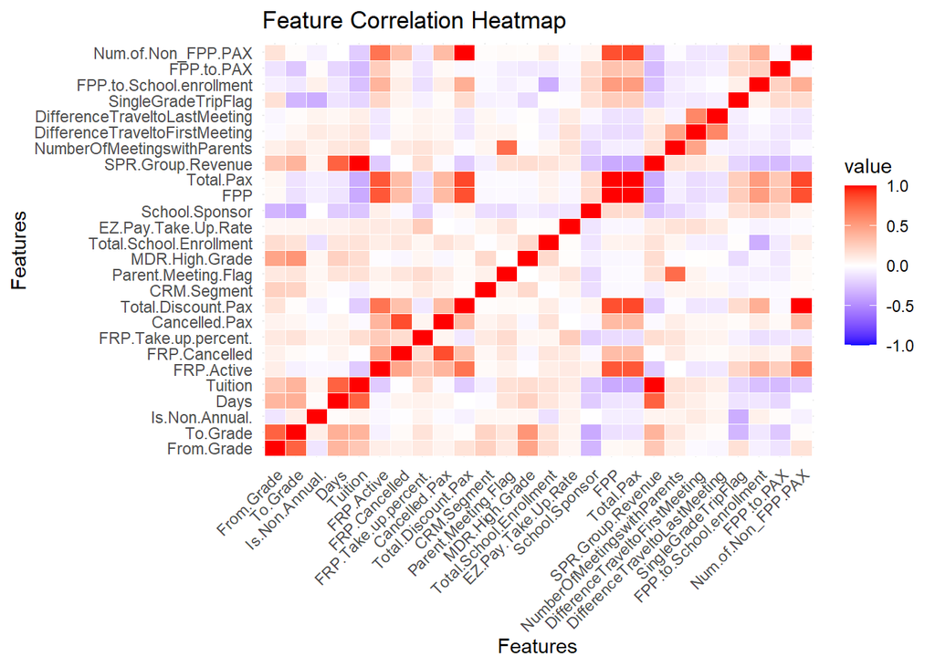

```r
# Melt the correlation matrix for visualization
correlation_melted <- melt(correlation_matrix)

# Plot the heatmap
ggplot(correlation_melted, aes(Var1, Var2, fill = value)) +
  geom_tile(color = "white") +
  scale_fill_gradient2(low = "blue", high = "red", mid = "white", midpoint = 0, limit = c(-1, 1), space = "Lab") +
  labs(title = "Feature Correlation Heatmap", x = "Features", y = "Features") +
  theme_minimal() +
  theme(axis.text.x = element_text(angle = 45, hjust = 1))
```

#Remove Highly Correlated Features

```r
# Keep only one feature from each highly correlated pair based on target correlation
features_to_remove <- c()
for (i in 1:nrow(high_corr_pairs)) {
  feature1 <- rownames(correlation_matrix)[high_corr_pairs[i, 1]]
  feature2 <- colnames(correlation_matrix)[high_corr_pairs[i, 2]]

  # Compare correlations with the target and decide which to keep
  if (abs(target_correlations[feature1]) >= abs(target_correlations[feature2])) {
    features_to_remove <- c(features_to_remove, feature2)
  } else {
    features_to_remove <- c(features_to_remove, feature1)
  }
}

# Remove Duplicates
features_to_remove <- unique(features_to_remove)

# Drop Features from the Dataset
data <- data[, !names(data) %in% features_to_remove]

cat("\nRemoved features due to high correlation:\n")
```

```
##
## Removed features due to high correlation:
```

```r
print(features_to_remove)
```

```
## [1] "Tuition"            "FRP.Active"         "Cancelled.Pax"
## [4] "Total.Discount.Pax" "Total.Pax"          "Num.of.Non_FPP.PAX"
## [7] "SPR.Group.Revenue"
```

#Drop Low Correlation Features

```r
# Drop features with low correlation to the target variable
low_correlation_features <- names(sorted_correlations[sorted_correlations < 0.1])
low_correlation_features
```

```
##  [1] "DifferenceTraveltoLastMeeting" "Total.School.Enrollment"
##  [3] "From.Grade"                    "FRP.Cancelled"
##  [5] "FPP.to.School.enrollment"      "NumberOfMeetingswithParents"
##  [7] "Days"                          "Cancelled.Pax"
##  [9] "Parent.Meeting.Flag"           "EZ.Pay.Take.Up.Rate"
## [11] "FRP.Take.up.percent."          "CRM.Segment"
```

```r
data <- data[, !names(data) %in% low_correlation_features]
```

#Corelations after dropping

```r
# Select only numeric columns (excluding the target variable)
numeric_columns <- names(data)[sapply(data, is.numeric)]
numeric_features <- numeric_columns[numeric_columns != "Retained.in.2012."]

# Compute the correlation matrix
correlation_matrix <- cor(data[, numeric_features], use = "pairwise.complete.obs")

# Find highly correlated pairs (correlation > 0.8 or < -0.8)
high_corr_pairs <- which(abs(correlation_matrix) > 0.8, arr.ind = TRUE)

# Exclude diagonal elements (self-correlations)
high_corr_pairs <- high_corr_pairs[high_corr_pairs[, 1] != high_corr_pairs[, 2], ]

# Display the highly correlated pairs
if (nrow(high_corr_pairs) > 0) {
  cat("Highly correlated pairs:\n")
  for (i in 1:nrow(high_corr_pairs)) {
    cat(rownames(correlation_matrix)[high_corr_pairs[i, 1]],
        "and",
        colnames(correlation_matrix)[high_corr_pairs[i, 2]],
        "with correlation:",
        correlation_matrix[high_corr_pairs[i, 1], high_corr_pairs[i, 2]],
        "\n")
  }
} else {
  cat("No highly correlated pairs found.\n")
}
```

```
## No highly correlated pairs found.
```

```r
# Compute correlations of numeric features with the target variable
target_correlations <- sapply(numeric_features, function(col) {
  cor(data[[col]], data$Retained.in.2012., use = "pairwise.complete.obs")
})

# Sort features by their correlation with the target variable
sorted_correlations <- sort(abs(target_correlations), decreasing = TRUE)

# Display correlations with the target
cat("Correlation with Retained.in.2012.:\n")
```

```
## Correlation with Retained.in.2012.:
```

```r
print(sorted_correlations)
```

```
##            SingleGradeTripFlag                 Is.Non.Annual.
##                      0.4563590                      0.3908604
##                            FPP                       To.Grade
##                      0.2607210                      0.1939735
##                     FPP.to.PAX                 MDR.High.Grade
##                      0.1452189                      0.1324135
## DifferenceTraveltoFirstMeeting                 School.Sponsor
##                      0.1219666                      0.1203127
```

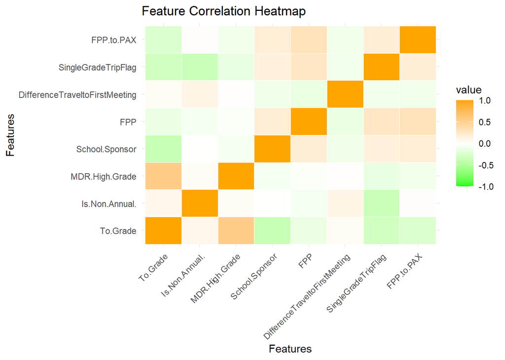

```r
# Melt the correlation matrix for visualization
correlation_melted <- melt(correlation_matrix)

# Plot the heatmap
ggplot(correlation_melted, aes(Var1, Var2, fill = value)) +
  geom_tile(color = "white") +
  scale_fill_gradient2(low = "green", high = "orange", mid = "white", midpoint = 0, limit = c(-1, 1), space = "Lab") +
  labs(title = "Feature Correlation Heatmap", x = "Features", y = "Features") +
  theme_minimal() +
  theme(axis.text.x = element_text(angle = 45, hjust = 1))
```

#Correlation with the Target Variable after remove high and low corelation variables

```r
# Compute correlations of numeric features with the target variable
target_correlations <- sapply(numeric_features, function(col) {
  cor(data[[col]], data$Retained.in.2012., use = "pairwise.complete.obs")
})

# Sort features by their correlation with the target variable
sorted_correlations <- sort(abs(target_correlations), decreasing = TRUE)

# Display correlations with the target
cat("Correlation with Retained.in.2012.:\n")
```

```
## Correlation with Retained.in.2012.:
```

```r
print(sorted_correlations)
```

```
##            SingleGradeTripFlag                 Is.Non.Annual.
##                      0.4563590                      0.3908604
##                            FPP                       To.Grade
##                      0.2607210                      0.1939735
##                     FPP.to.PAX                 MDR.High.Grade
##                      0.1452189                      0.1324135
## DifferenceTraveltoFirstMeeting                 School.Sponsor
##                      0.1219666                      0.1203127
```

#Univariate Analysis

Descriptive Statistics

```r
# Descriptive statistics for numeric variables
summary(data)
```

```
##  Program.Code          To.Grade      Group.State        Is.Non.Annual.
##  Length:2392        Min.   :0.0000   Length:2392        Min.   :0.0000
##  Class :character   1st Qu.:0.5556   Class :character   1st Qu.:0.0000
##  Mode  :character   Median :0.5556   Mode  :character   Median :0.0000
##                     Mean   :0.5465                      Mean   :0.1538
##                     3rd Qu.:0.5556                      3rd Qu.:0.0000
##                     Max.   :1.0000                      Max.   :1.0000
##  Travel.Type        Special.Pay        Poverty.Code          Region
##  Length:2392        Length:2392        Length:2392        Length:2392
##  Class :character   Class :character   Class :character   Class :character
##  Mode  :character   Mode  :character   Mode  :character   Mode  :character
##
##
##
##  School.Type        MDR.Low.Grade      MDR.High.Grade   Income.Level
##  Length:2392        Length:2392        Min.   :0.0000   Length:2392
##  Class :character   Class :character   1st Qu.:0.6364   Class :character
##  Mode  :character   Mode  :character   Median :0.6364   Mode  :character
##                                        Mean   :0.6709
##                                        3rd Qu.:0.6364
##                                        Max.   :1.0000
##  School.Sponsor   SPR.Product.Type   SPR.New.Existing        FPP
##  Min.   :0.0000   Length:2392        Length:2392        Min.   :0.00000
##  1st Qu.:0.0000   Class :character   Class :character   1st Qu.:0.03521
##  Median :0.0000   Mode  :character   Mode  :character   Median :0.07394
##  Mean   :0.1058                                         Mean   :0.10312
##  3rd Qu.:0.0000                                         3rd Qu.:0.13732
##  Max.   :1.0000                                         Max.   :1.00000
##  DifferenceTraveltoFirstMeeting SchoolGradeTypeLow SchoolGradeTypeHigh
##  Min.   :0.0000                 Length:2392        Length:2392
##  1st Qu.:0.4407                 Class :character   Class :character
##  Median :0.4764                 Mode  :character   Mode  :character
##  Mean   :0.4873
##  3rd Qu.:0.5047
##  Max.   :1.0000
##  SchoolGradeType    DepartureMonth     GroupGradeTypeLow  GroupGradeTypeHigh
##  Length:2392        Length:2392        Length:2392        Length:2392
##  Class :character   Class :character   Class :character   Class :character
##  Mode  :character   Mode  :character   Mode  :character   Mode  :character
##
##
##
##  GroupGradeType     MajorProgramCode   SingleGradeTripFlag   FPP.to.PAX
##  Length:2392        Length:2392        Min.   :0.0000      Min.   :0.0000
##  Class :character   Class :character   1st Qu.:0.0000      1st Qu.:0.7059
##  Mode  :character   Mode  :character   Median :1.0000      Median :0.7727
##                                        Mean   :0.5573      Mean   :0.7517
##                                        3rd Qu.:1.0000      3rd Qu.:0.8333
##                                        Max.   :1.0000      Max.   :1.0000
##  SchoolSizeIndicator Retained.in.2012.
##  Length:2392         Min.   :0.0000
##  Class :character    1st Qu.:0.0000
##  Mode  :character    Median :1.0000
##                      Mean   :0.6079
##                      3rd Qu.:1.0000
##                      Max.   :1.0000
```

```r
# View unique values for categorical variables
sapply(data, function(col) if (is.factor(col) || is.character(col)) unique(col))
```

```
## $Program.Code
##  [1] "HS"    "HC"    "HD"    "HN"    "SG"    "Other" "CC"    "CD"    "HVP"
## [10] "SM"    "HG"    "SK"    "SC"    "IC"    "ST"
##
## $To.Grade
## NULL
##
## $Group.State
##  [1] "CA"    "AZ"    "FL"    "VA"    "LA"    "MA"    "Other" "TX"    "IA"
## [10] "MI"    "NY"    "NC"    "OH"    "MN"    "IL"    "IN"    "WI"    "MO"
## [19] "ID"    "TN"    "KS"    "AL"    "KY"    "OR"    "NE"    "CO"    "NM"
## [28] "OK"    "GA"    "WA"    "NV"    "CT"    "MD"
##
## $Is.Non.Annual.
## NULL
##
## $Travel.Type
## [1] "A"     "B"     "Other"
##
## $Special.Pay
## [1] "FR" "CP" "SA"
##
## $Poverty.Code
## [1] "B"     "C"     "D"     "A"     "E"     "Other"
##
## $Region
## [1] "Southern California" "Other"               "Houston"
## [4] "Northern California" "Dallas"              "Pacific Northwest"
##
## $School.Type
## [1] "PUBLIC"                "CHD"                   "Catholic"
## [4] "Private non-Christian"
##
## $MDR.Low.Grade
##  [1] "K"     "7"     "6"     "Other" "9"     "PK"    "5"     "3"     "4"
## [10] "8"
##
## $MDR.High.Grade
## NULL
##
```

[output cut: 47 more lines]

```
##
## $MajorProgramCode
## [1] "H" "S" "I" "C"
##
## $SingleGradeTripFlag
## NULL
##
## $FPP.to.PAX
## NULL
##
## $SchoolSizeIndicator
## [1] "L"   "S-M" "M-L" "S"
##
## $Retained.in.2012.
## NULL
```

Visualizing Distributions For Numeric Variables: Use histograms or density plots.

```r
# Identify numeric and character columns
numeric_columns <- names(data)[sapply(data, is.numeric)]
character_columns <- names(data)[sapply(data, is.character)]

# Step 1: Process Numeric Columns (e.g., Histograms, Descriptive Statistics)
cat("Processing Numeric Columns:\n")
```

```
## Processing Numeric Columns:
```

```
##
## Summary of To.Grade :
##    Min. 1st Qu.  Median    Mean 3rd Qu.    Max.
##  0.0000  0.5556  0.5556  0.5465  0.5556  1.0000
```

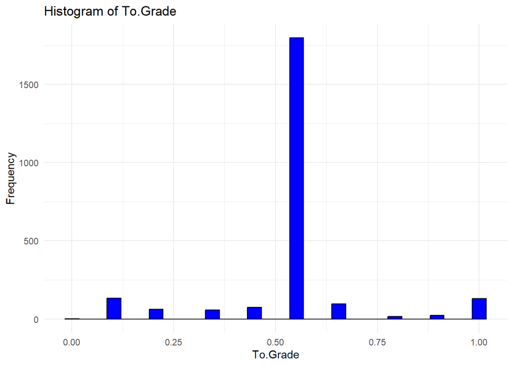

```
##
## Summary of Is.Non.Annual. :
##    Min. 1st Qu.  Median    Mean 3rd Qu.    Max.
##  0.0000  0.0000  0.0000  0.1538  0.0000  1.0000
```

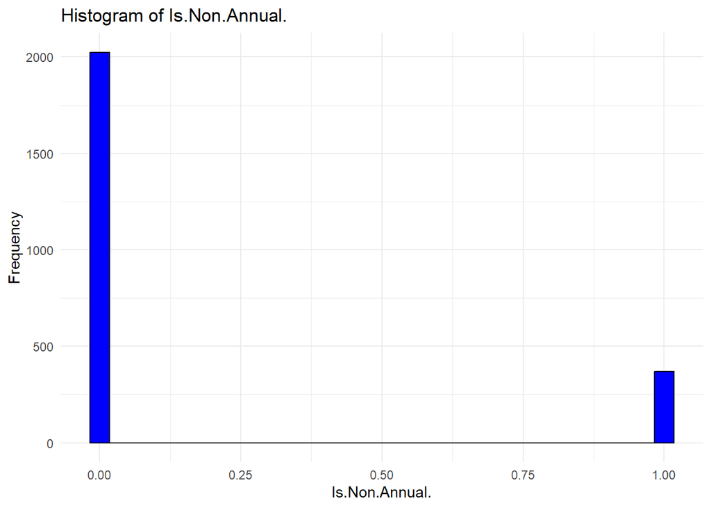

```
##
## Summary of MDR.High.Grade :
##    Min. 1st Qu.  Median    Mean 3rd Qu.    Max.
##  0.0000  0.6364  0.6364  0.6709  0.6364  1.0000
```

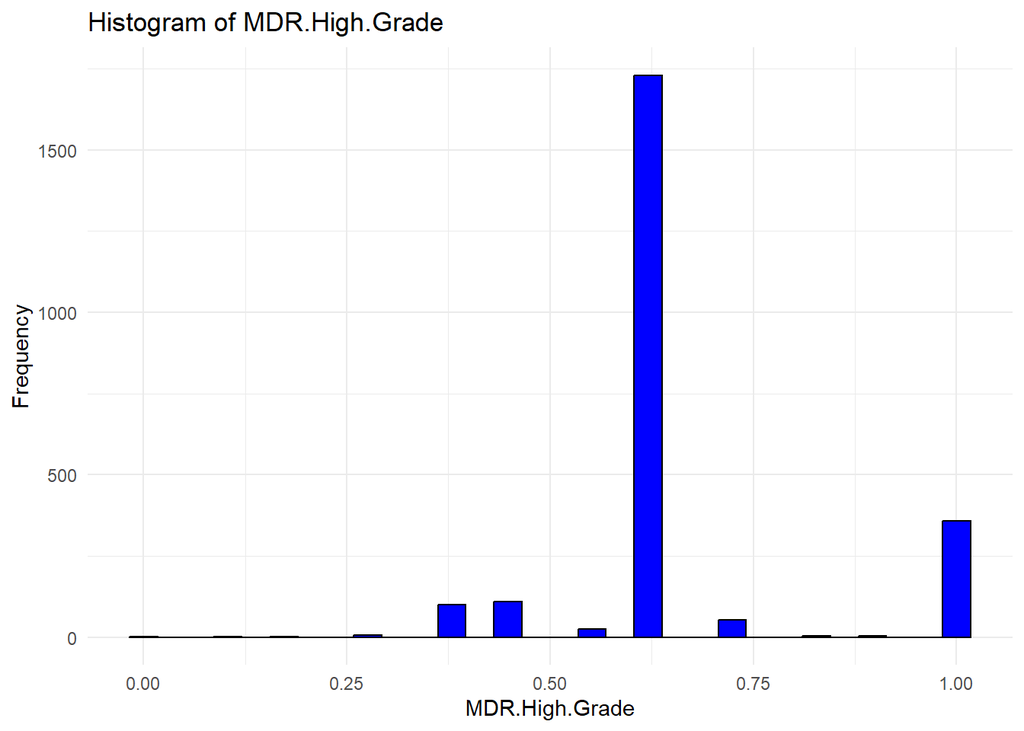

```
##
## Summary of School.Sponsor :
##    Min. 1st Qu.  Median    Mean 3rd Qu.    Max.
##  0.0000  0.0000  0.0000  0.1058  0.0000  1.0000
```

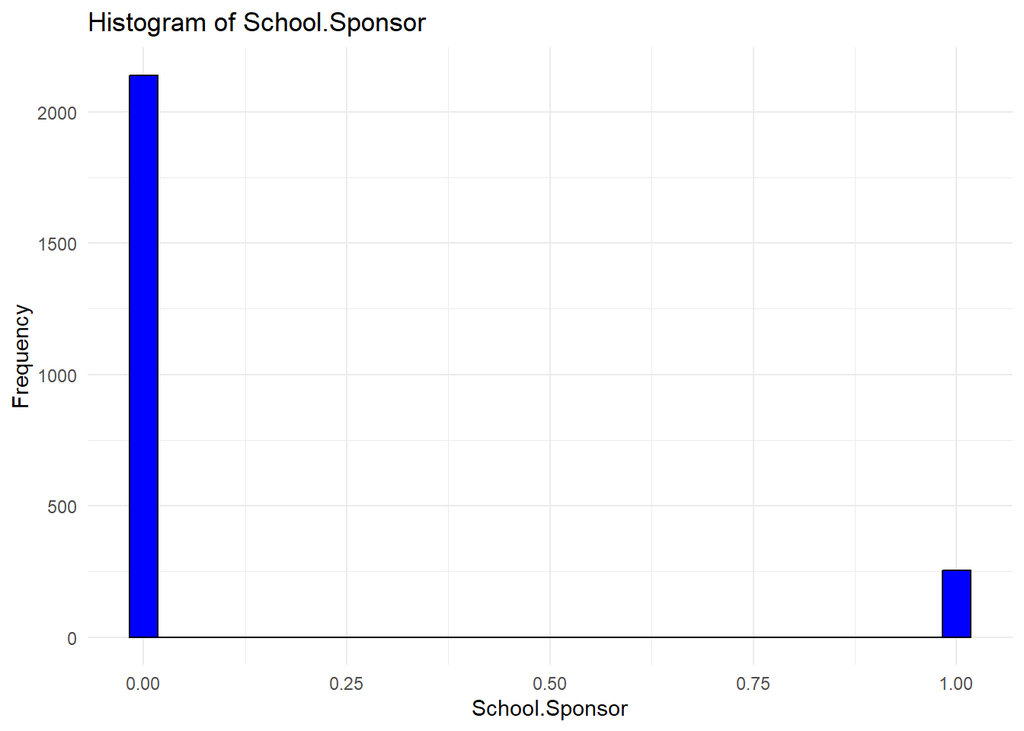

```
##
## Summary of FPP :
##    Min. 1st Qu.  Median    Mean 3rd Qu.    Max.
## 0.00000 0.03521 0.07394 0.10312 0.13732 1.00000
```

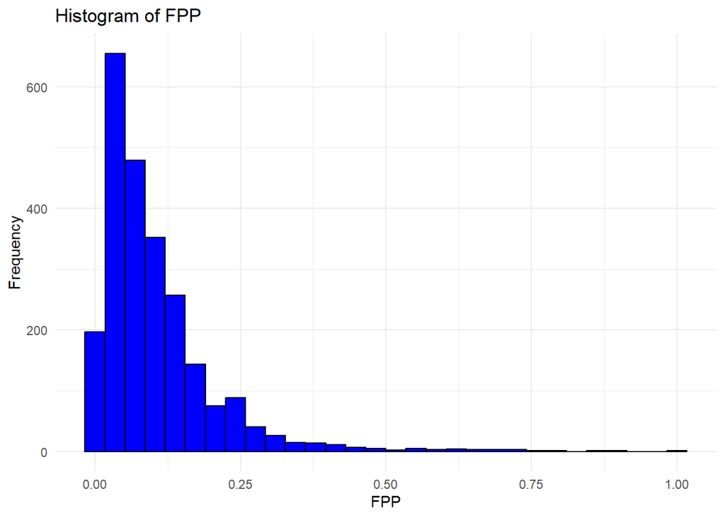

```
##
## Summary of DifferenceTraveltoFirstMeeting :
##    Min. 1st Qu.  Median    Mean 3rd Qu.    Max.
##  0.0000  0.4407  0.4764  0.4873  0.5047  1.0000
```

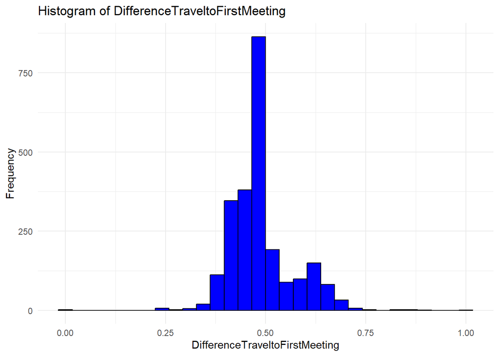

```
##
## Summary of SingleGradeTripFlag :
##    Min. 1st Qu.  Median    Mean 3rd Qu.    Max.
##  0.0000  0.0000  1.0000  0.5573  1.0000  1.0000
```

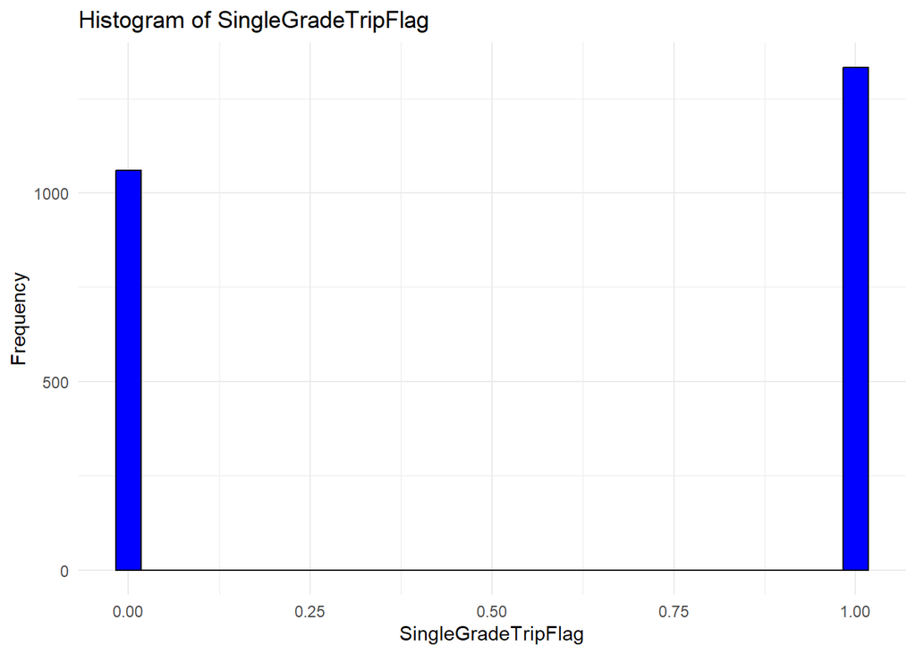

```
##
## Summary of FPP.to.PAX :
##    Min. 1st Qu.  Median    Mean 3rd Qu.    Max.
##  0.0000  0.7059  0.7727  0.7517  0.8333  1.0000
```

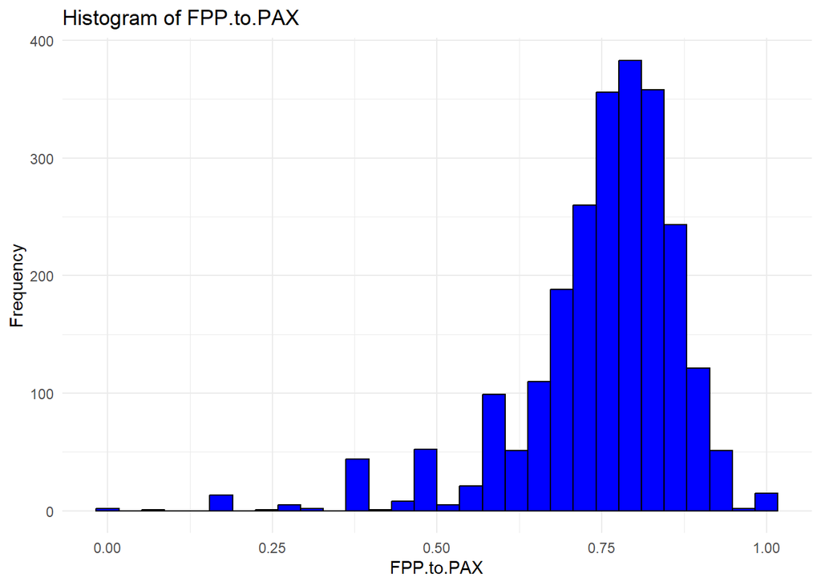

```
##
## Summary of Retained.in.2012. :
##    Min. 1st Qu.  Median    Mean 3rd Qu.    Max.
##  0.0000  0.0000  1.0000  0.6079  1.0000  1.0000
```

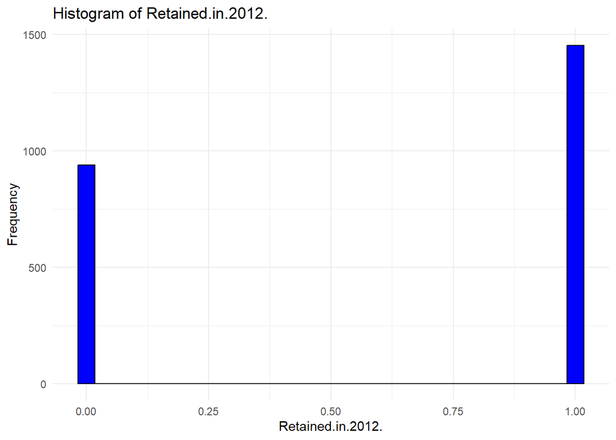

```r
for (col_name in numeric_columns) {
  cat("\nSummary of", col_name, ":\n")
  print(summary(data[[col_name]]))  # Print summary statistics

  # Plot histogram
  print(
    ggplot(data, aes_string(x = col_name)) +
      geom_histogram(fill = "blue", color = "black", bins = 30) +
      labs(title = paste("Histogram of", col_name), x = col_name, y = "Frequency") +
      theme_minimal()
  )
}
```

```r
# Step 2: Process Character Columns (e.g., Frequency Counts, Bar Plots)
cat("\nProcessing Character Columns:\n")
```

```
##
## Processing Character Columns:
```